# Expression de l'encodage des données

Pour entrer les données dans un circuit quantique, on pose l'expression suivante, provenant de notre article de référence :

$$ U(x) = W^{(2)} G(x) W^{(1)} $$

Cette expression ne dispose pas de référence connue sur le web ; néanmoins, elle est typique de ce qui se fait en matière d'encodage de données dans le domaine quantique.

Pour plus de détails, nous allons décomposer cette expression en deux étapes.

# L'Expression G(x)

Dans l'article support de cette étude, la porte encodeuse de données est assurée par cette expression :

$$ G(x) = e^{ixH} $$

- *i* : valeur irréelle telle que $ i^2 = -1 $
- *x* : ce sont les données à encoder
- *H* : l'opérateur Hamiltonien, choisi de manière arbitraire

D'après le [document](https://hillside.net/plop/2020/papers/proceedings/papers/02-weigold.pdf), cet encodage nous garantit une évolution unitaire. Elle est primordiale pour notre simulation quantique.

Lorsque l'on effectue des opérations, on cherche à garder cette borne entre 0 et 1 afin d'éviter des valeurs qui pourraient compromettre la stabilité des calculs.

On respecte la normalisation grâce à *H*, qui dépend des portes quantiques et repose elle-même sur cette normalisation. Nous détaillerons ensuite la représentation de *H*.

Cette équation trouve ses origines dans [la théorie des opérateurs](https://math.univ-lyon1.fr/~aubrun/enseignement/operateurs/cours.pdf). Nous ne détaillerons pas ici cette théorie.

On reste dans le cadre de la transformation unitaire : on modifie l'état d'un seul qubit et on respecte les règles fondamentales de la mécanique quantique en conservant la norme entre 0 et 1.

## Les Caractéristiques

Comme on l'a déjà dit, les caractéristiques sont représentées par la variable (*x*) dans notre fonction d'encodage.  
On sait que $ x \in \mathbb{R} $.

D'un point de vue mathématique, (*x*) est un vecteur de caractéristiques réelles.

$$ x = \begin{bmatrix} x_1, & x_2, & x_3, & \dots & x_n \end{bmatrix} $$

En programmation, on pourrait représenter (*x*), les *input features*, par :

```python
import numpy as np

input_feature =  np.array([1,2,3])
```

## L'opérateur Hamiltonien (H)

L'opérateur Hamiltonien est [une combinaison linéaire](https://docs.pennylane.ai/en/stable/code/api/pennylane.Hamiltonian.html) simple des portes quantiques que l'on applique sur un seul qubit.

D'après notre article, on définit *H* de la manière suivante :

$$ H = \gamma \sigma $$

avec $\ \ \ \sigma \in \{\sigma_x, \sigma_y, \sigma_z\}\ \ \ \ \ $ et $ \ \ \ \ \ \gamma = \frac{1}{2} \ \ \ \ \ $

Si vous lisez l'article (p4-(*)13), on retrouve un *gamma* défini arbitrairement à 0.5. Il représente le facteur de perte énergétique du qubit.

En règle générale, le qubit est défini sur les opérations de *Sigma*, les opérations *Pauli-x, y et z*, qui sont ni plus ni moins que des produits de matrices hermitiennes.

On retient que l'opérateur Hamiltonien est défini sur une décomposition arbitraire de *sigma*, d'opérations sur le qubit, les portes.

Comme le fait PennyLane [ici](https://docs.pennylane.ai/en/stable/code/api/pennylane.Hamiltonian.html), *H* se représente de la manière suivante :

$$ H = \sum_{k=0}^{N-1} c_k O_k $$

$c_k$ : Étant les coefficients multiplicateurs des opérations de rotation  
$O_k$ : Les opérations à appliquer sur le qubit

Comme nous avons un seul opérateur :

$$ H = k_{1} O_1 $$

Et que notre constante *gamma* est fixée à 0.5 :

$$ \gamma = k_{1} = 0.5 $$

$$ H = \frac{1}{2} \ (X \mid Y \mid Z) $$

$$ H = \frac{1}{2}O_1 \quad \text{avec} \quad O_{1} \in \{X, Y, Z\} $$

```python
from source.quantum_doors import *

class Pauli:
    X = quantum_door.X
    Y = quantum_door.Y
    Z = quantum_door.Z

# Définition de la fonction Hamiltonian

def Hamiltonian(pauli):

    # Liste des valeurs valides
    valid = [Pauli.X, Pauli.Y, Pauli.Z]

    # Parcourt chaque valeur valide et on retourne la porte Pauli modifiée
    if any(np.array_equal(pauli, valid_pauli) for valid_pauli in valid):

        return (1/2) * pauli

    else:

        # On lève une exception dans le cas contraire
        raise ValueError(f"Erreur : {pauli} n'est pas un Pauli valide")
```

## Définition de la fonction de l'encodage des données

Avec cette nouvelle définition de l'opérateur Hamiltonien, notre fonction d'encodage devient :

$$e^{ix\frac{1}{2}O_1}$$

soit

$$e^{i\frac{x}{2}O_1}$$

Avec cette nouvelle équation, on peut faire le lien avec l’opérateur de rotation de spin :

$$\mathrm{D}(y, t) = \exp \left( -i\frac{t}{2} \sigma_y \right)$$

$ y $ : une variable désignant une porte de Pauli, $ y \in \{X, Y, Z\} $  
$ t $ : étant les *input features*, notre $ x $

C'est ni plus ni moins que l'expression des opérateurs de rotation $Rx$, $Ry$, $Rz$, liés à $H$ dans notre cas.

On la représnete sour forme matricielle avec : $$ D(y,t)=\begin{pmatrix} \cos\left(\frac{t}{2}\right) & -\sin\left(\frac{t}{2}\right) \\ \sin\left(\frac{t}{2}\right) & \cos\left(\frac{t}{2}\right) \end{pmatrix} \times y $$

Pour en savoir plus sur les rotations de spin et les matrices de Pauli, consultez [cet article sur Wikipedia](https://en.wikipedia.org/wiki/Pauli_matrices).

Nous la programmons de la manière suivante :

```python
import numpy as np
from scipy.linalg import expm as exp

# On définit la fonction de la porte d'encodage G(x)

def G(qubit, x, pauli_operator=Pauli.X):

    # On construit la porte Hamiltonienne

    H = Hamiltonian(pauli_operator)

    encoded_matrix = np.eye(2, dtype=complex)  # Matrice identité 2x2
    encoded_matrix = encoded_matrix @ exp(1j * x * H)

    return encoded_matrix @ qubit
```

# L'ajout des portes W

D'après l'expression d'encodage générale :

$$ U(x) = W^{(2)} G(x) W^{(1)} $$

> "coefficients cω are determined by the arbitrary gates W(1) ...W(L+1)" - Page 4 sous la mention 11

On définit les valeurs *W* comme une porte arbitraire. Cette argumentation repose sur ce [document](https://github.com/XanaduAI/expressive_power_of_quantum_models/blob/master/tutorial_expressivity_fourier_series.ipynb) :

On définit la porte de rotation *W* comme une porte de rotation *R* d'après [PennyLane](https://docs.pennylane.ai/en/stable/code/api/pennylane.Rot.html) :

$$ R(ϕ, θ, ω) = RZ(ω)\ RY(θ)\ RZ(ϕ) = \begin{pmatrix} e^{iϕ} \cos\left(\frac{\theta}{2}\right) & -e^{iω} \sin\left(\frac{\theta}{2}\right) \\ e^{-iω} \sin\left(\frac{\theta}{2}\right) & e^{-iϕ} \cos\left(\frac{\theta}{2}\right) \end{pmatrix} $$

La porte *R* est une combinaison de trois portes de rotation qui expriment une rotation arbitraire selon l'encodage que l'on souhaite mettre dans le code, où *ϕ* (*phi*), *θ* (*theta*) et *ω* (*omega*) sont les angles de rotation des qubits.

Généralement, les portes *R* prennent un *wire*, mais comme dans le code de configuration, nous passons cette étape pour éviter du code inutile.

On définit les portes *W* en Python de cette manière :

```python
# Définition de la porte R

def R(qubit, phi, theta, omega):
    new_qubit = quantum_door.RZ(qubit, omega)
    new_qubit = quantum_door.RY(new_qubit, theta)
    return quantum_door.RZ(new_qubit, phi)

# Définition de la porte W

def W(qubit, theta):
    return R(qubit, theta[0], theta[1], theta[2])
```

Et la fonction générale d'encodage U(X) :

```python
# Définition de U

def U(qubit, weights, X=None):

    # On définit les portes W selon les paramètres arbitraires

    for theta in weights:

        for x in X :
            qubit = W(qubit, theta)
            qubit = G(qubit, x)

    qubit = W(qubit, weights[-1])

    # On applique la fonction U

    return qubit
```

## Exemple d'utilisation de la fonction d'encodage

Nous allons utiliser l'encodage d'une image du numéro du dataset connu de digits dans la bibliothèque de Scikit-learn.

```
Image à encoder :
```

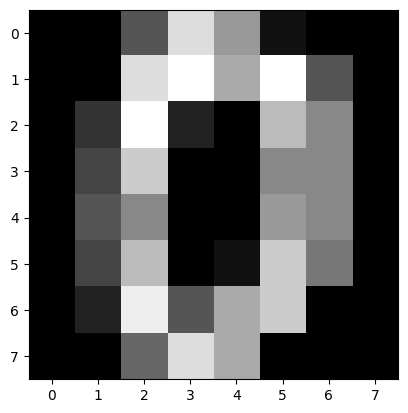

```python
from sklearn.datasets import load_digits
import matplotlib.pyplot as plt

# On charge le dataset des digits
digits = load_digits()

# On prend la première image que l'on convertit en matrice carrée
image = np.array(digits.data[0]).reshape(8, 8)

# On l'affiche
print("Image à encoder :")
plt.imshow(image, cmap="gray", interpolation="nearest")
plt.show()
```

Maintenant que nous avons l'image, on va l'encoder en définissant un qubit en position fondamentale $|0\rangle$.

Dans tout processus d'encodage quantique ou de deep learning quantique, les qubits seront initialisés de cette manière. Elles servent de point initial, comme pour le bit classique avec une valeur à 0.

```
État du qubit avant l'encodage :
[1 0]
phi(0.0), theta(0.0)
Probabilité d'avoir 0 : 100 %
Probabilité d'avoir 1 : 0 %

État du qubit après l'encodage :
[ 0.52756186-0.80109485j -0.28261444+0.00738932j]
phi(178.50226854141064), theta(133.16545987982806)
Probabilité d'avoir 0 : 92.00744744052305 %
Probabilité d'avoir 1 : 7.992552559477358 %
```

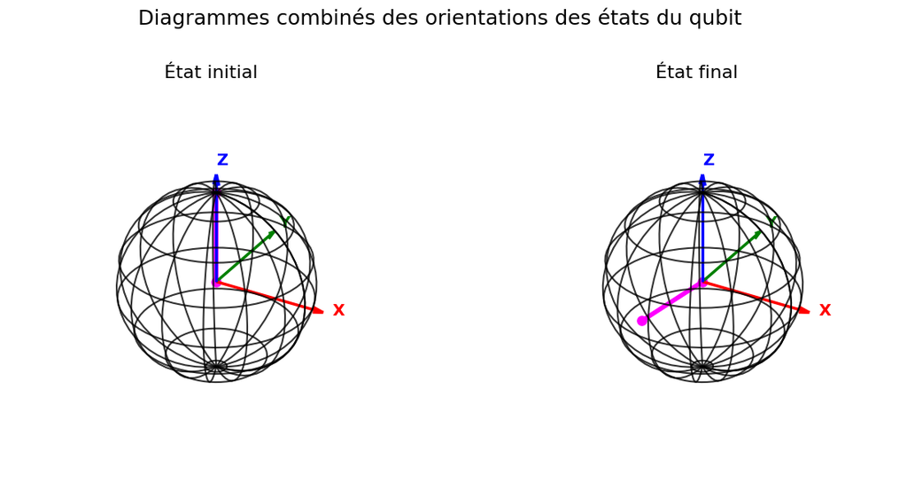

```python
from source.quantum_utils import *
from source.qubit_3D_simulation import *

# On initialise le qubit en position fondamentale

alpha = 1
beta = 0

qubit_fondamental = np.array([alpha, beta])

print("\nÉtat du qubit avant l'encodage : ")
quantum.show(qubit_fondamental)

# On extrait les features de l'image de manière très simple, en calculant la variance sur une redimension en 2 colonnes de l'image

input_features = image.reshape(-1, 1)

weights = 2 * np.pi * np.random.random(size=(2, 3))
# On définit la porte sur les features extraites avec une rotation arbitraire X

new_qubit = U(qubit_fondamental, weights, input_features)

# On fait un produit scalaire de la nouvelle porte sur le qubit en état fondamental

print("\nÉtat du qubit après l'encodage : ")
quantum.show(new_qubit)

plot_combined_snapshots(qubit_fondamental, new_qubit,
                        "Diagrammes combinés des orientations des états du qubit")
```